# FF_Practice_act_9.2

Our dataset consists of clinical data from patients who entered the hospital complaining of chest pain (“angina”) during exercise. The information collected includes:

- `age` : Age of the patient
- `sex` : Sex of the patient
- `cp` : Chest Pain type
  - Value 0: asymptomatic
  - Value 1: typical angina
  - Value 2: atypical angina
  - Value 3: non-anginal pain
- `trtbps` : resting blood pressure (in mm Hg)
- `chol` : cholesterol in mg/dl fetched via BMI sensor
- `restecg` : resting electrocardiographic results
  - Value 0: normal
  - Value 1: having ST-T wave abnormality (T wave inversions and/or ST elevation or depression of > 0.05 mV)
  - Value 2: showing probable or definite left ventricular hypertrophy by Estes’ criteria
- `thalach` : maximum heart rate achieved during exercise
- `output` : the doctor’s diagnosis of whether the patient is at risk for a heart attack
  - 0 = not at risk of heart attack
  - 1 = at risk of heart attack

```python
import pandas as pd
import numpy as np
from sklearn.pipeline import Pipeline
from sklearn.neighbors import KNeighborsClassifier
from sklearn.tree import DecisionTreeClassifier, plot_tree
from sklearn.linear_model import LogisticRegression
from sklearn.compose import make_column_selector, ColumnTransformer
from sklearn.preprocessing import StandardScaler, OneHotEncoder, PolynomialFeatures
from sklearn.model_selection import train_test_split, cross_val_score, GridSearchCV
from sklearn.metrics import roc_curve, auc, confusion_matrix, accuracy_score, recall_score, precision_score, cohen_kappa_score
from plotnine import *
from sklearn.discriminant_analysis import LinearDiscriminantAnalysis as LDA
from sklearn.svm import SVC
```

```python
#ignore warnings
import warnings
from sklearn.exceptions import DataConversionWarning

warnings.filterwarnings(action='ignore', category=DataConversionWarning)
```

```python
ha = pd.read_csv("https://www.dropbox.com/s/aohbr6yb9ifmc8w/heart_attack.csv?dl=1")
```

```python
X = ha.drop('cp', axis=1)
y = ha['cp']
```

## Q1: Natural Multiclass Models

Fit a multiclass KNN, Decision Tree, and LDA for the heart disease data; this time predicting the type of chest pain (categories 0 - 3) that a patient experiences. For the decision tree, plot the fitted tree, and interpret the first couple splits.

```python
def cat_roc(explanatory, target, modeltype, *args, **argsnum):

  X = explanatory
  y = target

  # finding the best model

  categorical_features = ['output', 'restecg','sex']
  numeric_features = ['age', 'trtbps', 'chol', 'thalach']

  ct = ColumnTransformer([
        ('dummify', OneHotEncoder(handle_unknown='ignore'),
        categorical_features),
        ("standardize", StandardScaler(), numeric_features)
    ],
    remainder="passthrough")

  model_pipeline = Pipeline([
        ("preprocessing", ct),
        ("model", modeltype(*args))
    ])
  degree = {'model__' + key: np.array(value) for key, value in argsnum.items()}

  gscv = GridSearchCV(model_pipeline, degree, cv = 5, scoring='accuracy')

  tuning = gscv.fit(X, y)

  result = pd.DataFrame(tuning.cv_results_).sort_values(by='rank_test_score', ascending=True).head(1)

  # using the best model and getting the confusion matrix

  best_model = tuning.best_estimator_

  return result, best_model
```

```python
knn_result, knn_model = cat_roc(ha.drop('cp', axis=1), ha['cp'], KNeighborsClassifier, n_neighbors=[1,3,5,7,10,15,20,30])
knn_result
```

|  | mean_fit_time | std_fit_time | mean_score_time | std_score_time | param_model__n_neighbors | params | split0_test_score | split1_test_score | split2_test_score | split3_test_score | split4_test_score | mean_test_score | std_test_score | rank_test_score |
| --- | --- | --- | --- | --- | --- | --- | --- | --- | --- | --- | --- | --- | --- | --- |
| 6 | 0.013595 | 0.001317 | 0.015778 | 0.001433 | 20 | {'model__n_neighbors': 20} | 0.363636 | 0.6 | 0.654545 | 0.648148 | 0.444444 | 0.542155 | 0.117157 | 1 |

```python
dt_result, dt_model = cat_roc(ha.drop('cp', axis=1), ha['cp'], DecisionTreeClassifier, max_depth = [None, 1,2,3,4,10,20], min_samples_leaf = [1,3,5,10,20,50], min_impurity_decrease=[.001,.01,.05,.08,.15])
dt_result
```

|  | mean_fit_time | std_fit_time | mean_score_time | std_score_time | param_model__max_depth | param_model__min_impurity_decrease | param_model__min_samples_leaf | params | split0_test_score | split1_test_score | split2_test_score | split3_test_score | split4_test_score | mean_test_score | std_test_score | rank_test_score |
| --- | --- | --- | --- | --- | --- | --- | --- | --- | --- | --- | --- | --- | --- | --- | --- | --- |
| 104 | 0.009473 | 0.000346 | 0.005882 | 0.000186 | 3 | 0.05 | 5 | {'model__max_depth': 3, 'model__min_impurity_d... | 0.309091 | 0.618182 | 0.763636 | 0.722222 | 0.462963 | 0.575219 | 0.16875 | 1 |

```python
lda_result, lda_model = cat_roc(ha.drop('cp', axis=1),ha['cp'],  LDA)

lda_result
```

|  | mean_fit_time | std_fit_time | mean_score_time | std_score_time | params | split0_test_score | split1_test_score | split2_test_score | split3_test_score | split4_test_score | mean_test_score | std_test_score | rank_test_score |
| --- | --- | --- | --- | --- | --- | --- | --- | --- | --- | --- | --- | --- | --- |
| 0 | 0.010338 | 0.001613 | 0.005485 | 0.000351 | {} | 0.309091 | 0.6 | 0.654545 | 0.685185 | 0.407407 | 0.531246 | 0.147184 | 1 |

```python
knn_fitted = knn_model.fit(X,y)
dt_fitted = dt_model.fit(X,y)
lda_fitted = lda_model.fit(X,y)
```

```
[Text(0.5, 0.75, 'x[0] <= 0.5\ngini = 0.661\nsamples = 273\nvalue = [128, 44, 81, 20]'),
```

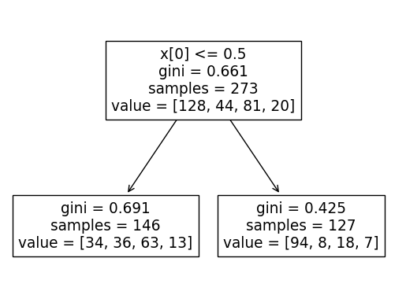

```python
plot_tree(dt_fitted["model"])
```

## Q2: OvR

Create a new column in the `ha` dataset called `cp_is_3`, which is equal to `1` if the `cp` variable is equal to `3` and `0` otherwise.

Then, fit a Logistic Regression to predict this new target, and report the **F1 Score**.

Repeat for the other three `cp` categories. Which category was the OvR approach best at distinguishing? It was best at disguinshing between 0 and the rest.

```python
ha['cp_is_3'] = (ha['cp'] == 3).astype(int)
ha['cp_is_2'] = (ha['cp'] == 2).astype(int)
ha['cp_is_1'] = (ha['cp'] == 1).astype(int)
ha['cp_is_0'] = (ha['cp'] == 0).astype(int)
```

```python
X = ha.drop(["cp", "cp_is_2", "cp_is_3", "cp_is_1", "cp_is_0"],axis=1)
y= ha[["cp_is_3"]]
```

```python
def cat_roc(colunm, modeltype, *args, **argsnum):

  X = ha.drop(["cp", "cp_is_2", "cp_is_3", "cp_is_1","cp_is_0"],axis=1)
  y= ha[[colunm]]

  # finding the best model

  categorical_features = ['output', 'restecg','sex']
  numeric_features = ['age', 'trtbps', 'chol', 'thalach']

  ct = ColumnTransformer([
        ('dummify', OneHotEncoder(handle_unknown='ignore'),
        categorical_features),
        ("standardize", StandardScaler(), numeric_features)
    ],
    remainder="passthrough")

  model_pipeline = Pipeline([
        ("preprocessing", ct),
        ("model", modeltype(*args))
    ])
  degree = {'model__' + key: np.array(value) for key, value in argsnum.items()}

  gscv = GridSearchCV(model_pipeline, degree, cv = 5, scoring='f1')

  tuning = gscv.fit(X, y)

  result = pd.DataFrame(tuning.cv_results_).sort_values(by='rank_test_score', ascending=True).head(1)

  # using the best model and getting the confusion matrix

  best_model = tuning.best_estimator_

  return result, best_model
```

```python
cp3_result, cp3best_model = cat_roc("cp_is_3", LogisticRegression, solver=['saga'], penalty=['elasticnet'], l1_ratio=[0, 0.25, 0.5, 0.75, 1])
cp2_result, cp2_best_model = cat_roc("cp_is_2", LogisticRegression, solver=['saga'], penalty=['elasticnet'], l1_ratio=[0, 0.25, 0.5, 0.75, 1])
cp1_result, cp1_best_model = cat_roc("cp_is_1", LogisticRegression, solver=['saga'], penalty=['elasticnet'], l1_ratio=[0, 0.25, 0.5, 0.75, 1])
cp0_result, cp0_best_model = cat_roc("cp_is_0", LogisticRegression, solver=['saga'], penalty=['elasticnet'], l1_ratio=[0, 0.25, 0.5, 0.75, 1])
```

```python
cp3_result
```

|  | mean_fit_time | std_fit_time | mean_score_time | std_score_time | param_model__l1_ratio | param_model__penalty | param_model__solver | params | split0_test_score | split1_test_score | split2_test_score | split3_test_score | split4_test_score | mean_test_score | std_test_score | rank_test_score |
| --- | --- | --- | --- | --- | --- | --- | --- | --- | --- | --- | --- | --- | --- | --- | --- | --- |
| 0 | 0.014973 | 0.000705 | 0.012015 | 0.001514 | 0.0 | elasticnet | saga | {'model__l1_ratio': 0.0, 'model__penalty': 'el... | 0.0 | 0.0 | 0.0 | 0.0 | 0.0 | 0.0 | 0.0 | 1 |

```python
cp2_result
```

|  | mean_fit_time | std_fit_time | mean_score_time | std_score_time | param_model__l1_ratio | param_model__penalty | param_model__solver | params | split0_test_score | split1_test_score | split2_test_score | split3_test_score | split4_test_score | mean_test_score | std_test_score | rank_test_score |
| --- | --- | --- | --- | --- | --- | --- | --- | --- | --- | --- | --- | --- | --- | --- | --- | --- |
| 4 | 0.013169 | 0.001752 | 0.011431 | 0.001021 | 1.0 | elasticnet | saga | {'model__l1_ratio': 1.0, 'model__penalty': 'el... | 0.431373 | 0.25 | 0.111111 | 0.0 | 0.0 | 0.158497 | 0.164513 | 1 |

```python
cp1_result
```

|  | mean_fit_time | std_fit_time | mean_score_time | std_score_time | param_model__l1_ratio | param_model__penalty | param_model__solver | params | split0_test_score | split1_test_score | split2_test_score | split3_test_score | split4_test_score | mean_test_score | std_test_score | rank_test_score |
| --- | --- | --- | --- | --- | --- | --- | --- | --- | --- | --- | --- | --- | --- | --- | --- | --- |
| 0 | 0.014682 | 0.000515 | 0.011288 | 0.000423 | 0.0 | elasticnet | saga | {'model__l1_ratio': 0.0, 'model__penalty': 'el... | 0.0 | 0.0 | 0.0 | 0.0 | 0.0 | 0.0 | 0.0 | 1 |

```python
cp0_result
```

|  | mean_fit_time | std_fit_time | mean_score_time | std_score_time | param_model__l1_ratio | param_model__penalty | param_model__solver | params | split0_test_score | split1_test_score | split2_test_score | split3_test_score | split4_test_score | mean_test_score | std_test_score | rank_test_score |
| --- | --- | --- | --- | --- | --- | --- | --- | --- | --- | --- | --- | --- | --- | --- | --- | --- |
| 3 | 0.01635 | 0.002518 | 0.012037 | 0.000671 | 0.75 | elasticnet | saga | {'model__l1_ratio': 0.75, 'model__penalty': 'e... | 0.0 | 0.818182 | 0.962963 | 0.851852 | 0.632911 | 0.653182 | 0.343429 | 1 |

## Q3: OvO

Reduce your dataset to only the `0` and `1` types of chest pain.

Then, fit a Logistic Regression to predict between the two groups, and report the **ROC-AUC**.

Repeat comparing category `0` to `2` and `3`. Which pair was the OvO approach best at distinguishing?

It was the best at distinguishing between 0 and 1.

```python
mask01 = ((ha['cp'] == 0) | (ha['cp'] == 1))
mask02 = ((ha['cp'] == 0) | (ha['cp'] == 2))
mask03 = ((ha['cp'] == 0) | (ha['cp'] == 3))

df01 = ha[mask01]
df02 = ha[mask02]
df03 = ha[mask03]
```

```python
def cat_roc(frame, modeltype, *args, **argsnum):

  X = frame.drop(["cp", "cp_is_2", "cp_is_3", "cp_is_1","cp_is_0"],axis=1)
  y= frame[["cp_is_0"]]

  # finding the best model

  categorical_features = ['output', 'restecg','sex']
  numeric_features = ['age', 'trtbps', 'chol', 'thalach']

  ct = ColumnTransformer([
        ('dummify', OneHotEncoder(handle_unknown='ignore'),
        categorical_features),
        ("standardize", StandardScaler(), numeric_features)
    ],
    remainder="passthrough")

  model_pipeline = Pipeline([
        ("preprocessing", ct),
        ("model", modeltype(*args))
    ])
  degree = {'model__' + key: np.array(value) for key, value in argsnum.items()}

  gscv = GridSearchCV(model_pipeline, degree, cv = 5, scoring='roc_auc')

  tuning = gscv.fit(X, y)

  result = pd.DataFrame(tuning.cv_results_).sort_values(by='rank_test_score', ascending=True).head(1)

  # using the best model and getting the confusion matrix

  best_model = tuning.best_estimator_

  return result
```

```python
cat_roc(df01, LogisticRegression, solver=['saga'], penalty=['elasticnet'], l1_ratio=[0, 0.25, 0.5, 0.75, 1])
```

|  | mean_fit_time | std_fit_time | mean_score_time | std_score_time | param_model__l1_ratio | param_model__penalty | param_model__solver | params | split0_test_score | split1_test_score | split2_test_score | split3_test_score | split4_test_score | mean_test_score | std_test_score | rank_test_score |
| --- | --- | --- | --- | --- | --- | --- | --- | --- | --- | --- | --- | --- | --- | --- | --- | --- |
| 4 | 0.011777 | 0.000821 | 0.012141 | 0.002684 | 1.0 | elasticnet | saga | {'model__l1_ratio': 1.0, 'model__penalty': 'el... | 0.782051 | 0.940171 | 0.96 | 0.942222 | 0.677885 | 0.860466 | 0.11174 | 1 |

```python
cat_roc(df02, LogisticRegression, solver=['saga'], penalty=['elasticnet'], l1_ratio=[0, 0.25, 0.5, 0.75, 1])
```

|  | mean_fit_time | std_fit_time | mean_score_time | std_score_time | param_model__l1_ratio | param_model__penalty | param_model__solver | params | split0_test_score | split1_test_score | split2_test_score | split3_test_score | split4_test_score | mean_test_score | std_test_score | rank_test_score |
| --- | --- | --- | --- | --- | --- | --- | --- | --- | --- | --- | --- | --- | --- | --- | --- | --- |
| 4 | 0.013481 | 0.002873 | 0.011661 | 0.003253 | 1.0 | elasticnet | saga | {'model__l1_ratio': 1.0, 'model__penalty': 'el... | 0.548235 | 0.778846 | 0.985577 | 0.9375 | 0.615 | 0.773032 | 0.171911 | 1 |

```python
cat_roc(df03, LogisticRegression, solver=['saga'], penalty=['elasticnet'], l1_ratio=[0, 0.25, 0.5, 0.75, 1])
```

|  | mean_fit_time | std_fit_time | mean_score_time | std_score_time | param_model__l1_ratio | param_model__penalty | param_model__solver | params | split0_test_score | split1_test_score | split2_test_score | split3_test_score | split4_test_score | mean_test_score | std_test_score | rank_test_score |
| --- | --- | --- | --- | --- | --- | --- | --- | --- | --- | --- | --- | --- | --- | --- | --- | --- |
| 2 | 0.013138 | 0.000527 | 0.0133 | 0.004763 | 0.5 | elasticnet | saga | {'model__l1_ratio': 0.5, 'model__penalty': 'el... | 0.442308 | 0.894231 | 1.0 | 0.87 | 0.47 | 0.735308 | 0.232249 | 1 |